# Statistical Rethinking: Chapter 4

# Linear Models

## Why normal distributions are normal

### Normal by Addition

Lets plot the distribution for 1,000 coin flips where each person gets a random number from a list of 16 between -1 and 1.

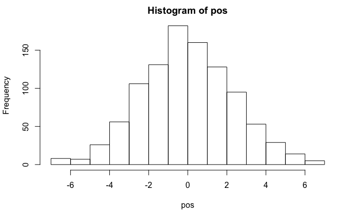

```r
pos <- replicate(n = 1000, expr = sum(runif(16, -1, 1)))
hist(pos)
```

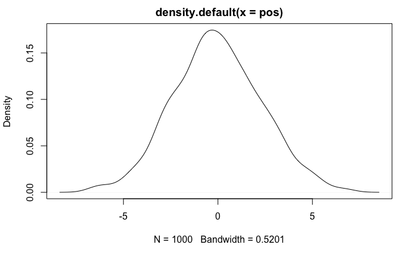

```r
plot(density(pos))
```

Any process that adds random values from the same distribution converges to a normal. Whatever the average value of the source distribution, each sample ffrom it can be thought of as a fluctuation from that average value. When we add these together, they begin to cancel one another out.

### Normal by multiplication

Suppose the growth rate of an organism is influenced by a dozen loci, each with several alleles that code for more growth. SUppose they all interact with one another, suhc that each increase growth by a percentage. This means that their effects multiply, rathen than add.

```r
library(rethinking)
prod(1 + runif(12, 0, 0.1))
```

```
[1] 1.821409
```

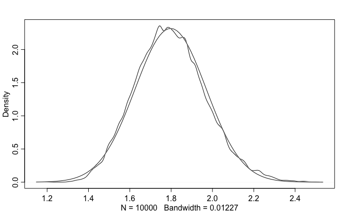

```r
growth <- replicate(10000, prod(1 + runif(12, 0, 0.1)))
dens(growth, norm.comp = TRUE)
```

Multiplicative terms approximate normality by addition if the values are small enough:

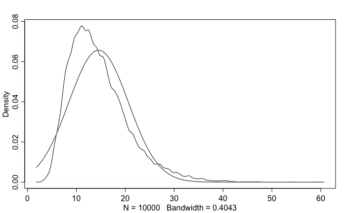

```r
big <- replicate(10000, prod(1 + runif(12, 0, 0.5)))
dens(big, norm.comp = TRUE)
```

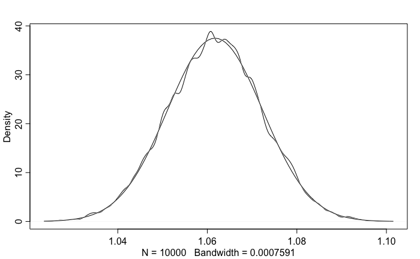

```r
small <- replicate(10000, prod(1 + runif(12, 0, 0.01)))
dens(small, norm.comp = TRUE)
```

### Normal by log-multiplacation

Big deviations produce a normal on the log scale

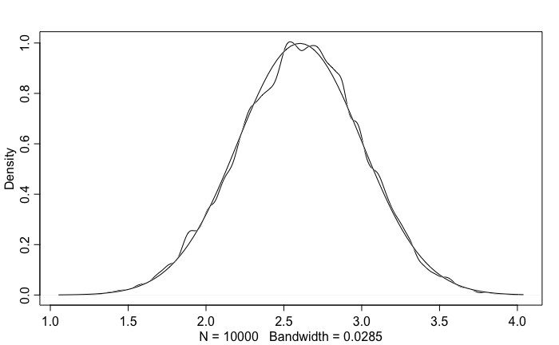

```r
log.big <- replicate(10000, log(prod(1 + runif(12, 0, 0.5))))
dens(log.big, norm.comp = TRUE)
```

## A language for describing models

1. First, we recgonize a set of measurements that we hope to predict or understand, the outcome variable or variables.
2. for each of these outcome variables, we define a likelihood distribution that defines the plausibility of individual observations. In linear regression, this distribution is always Gaussian.
3. Then we recognize a set of other measurements that we hope to use to predict or understand the outcome. Call these **predictor** variables.
4. We relate the exact shape of the likelihood distribution - its precise location and varance and other aspects of its shape, if it has them - to the predictor variables. In choosing a way to relate the predictors to the outcomes, we are forced to name and define all of the parameters of the model.
5. Finally, we choose priors for all of the parameters in the model. These priors define the initial information state of the model, before seeing the data.

$$\begin{aligned}
\text{outcome}_i &\sim \text{Normal}(\mu_i, \sigma) \\
\mu_i &= \beta \text{ x predictor}_i \\
\beta &\sim \text{Normal}(0, 10) \\
\sigma &\sim \text{HalfCauchy}(0, 1)
\end{aligned}$$

## A Gaussian model of height

### The data

```r
library(rethinking)
data("Howell1")
d <- Howell1
str(d)
```

```
'data.frame':   544 obs. of  4 variables:
 $ height: num  152 140 137 157 145 ...
 $ weight: num  47.8 36.5 31.9 53 41.3 ...
 $ age   : num  63 63 65 41 51 35 32 27 19 54 ...
 $ male  : int  1 0 0 1 0 1 0 1 0 1 ...
```

Filter the data down to individuals of age 18 or greater with:

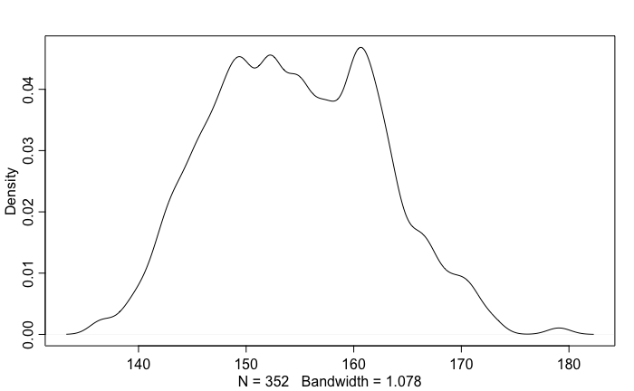

```r
d2 <- d[d$age >= 18, ]
dens(d2$height)
```

Define the heights as normally distributed with a mean and varance along with priors:

$$\begin{aligned}
h_i &\sim \text{Normal}(\mu, \sigma) \\
\mu &\sim \text{Normal}(178, 20) \\
\sigma &\sim \text{Uniform}(0, 50)
\end{aligned}$$

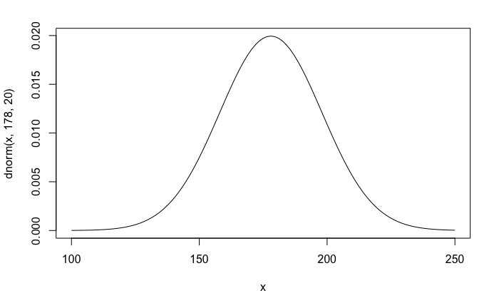

```r
curve(dnorm(x, 178, 20), from = 100, to = 250)
```

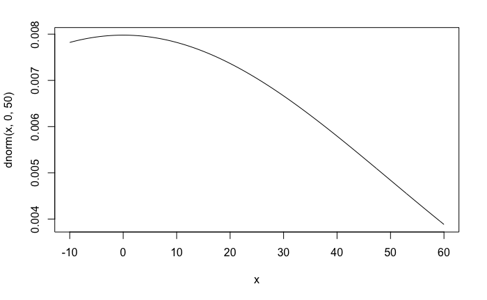

```r
curve(dnorm(x, 0, 50), from = -10, to = 60)
```

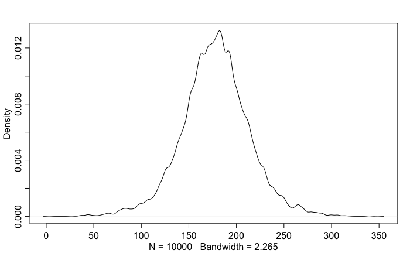

```r
sample_mu <- rnorm(10000, 178, 20)
sample_sigma <- runif(10000, 0, 50)
prior_h <- rnorm(10000, sample_mu, sample_sigma)
dens(prior_h)
```

### Grid approximationo the posterior distribution

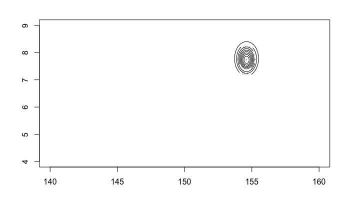

```r
mu.list <- seq(from = 140, to = 160, length.out = 200)
sigma.list <- seq(from = 4, to = 9, length.out = 200)
post <- expand.grid(mu = mu.list, sigma = sigma.list)
post$LL <- sapply(1:nrow(post), function(i) sum(dnorm(
  d2$height,
  mean = post$mu[i],
  sd = post$sigma[i],
  log = TRUE
)))
post$prod <- post$LL + dnorm(post$mu, 178, 20, TRUE) +
  dunif(post$sigma, 0, 50, TRUE)
post$prob <- exp(post$prod - max(post$prod))
contour_xyz(post$mu, post$sigma, post$prob)
```

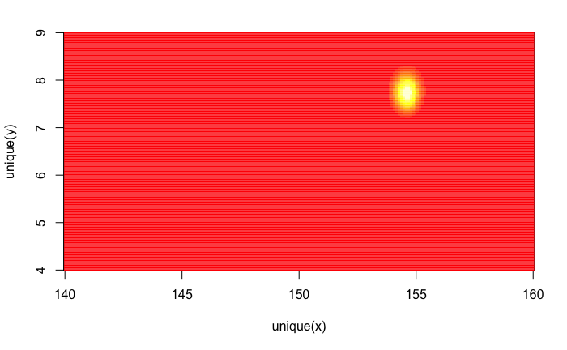

```r
image_xyz(post$mu, post$sigma, post$prob)
```

### Sampling from the posterior

First, we randomly sample row numbers in `post` in proportion to the values in `post$prob`. Then we pull out the parameter values on those randomly sampled rows.

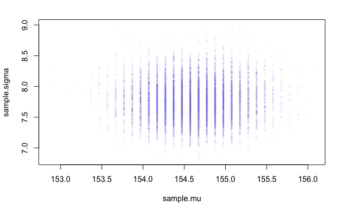

```r
sample.rows <- sample(1:nrow(post),
                      size = 10000,
                      replace = TRUE,
                      prob = post$prob)
sample.mu <- post$mu[sample.rows]
sample.sigma <- post$sigma[sample.rows]
plot(sample.mu, sample.sigma, cex = 0.5, pch = 16, col = col.alpha(rangi2, 0.1))
```

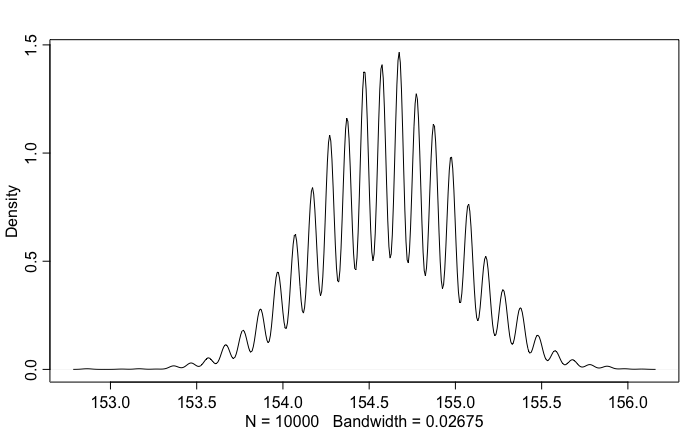

```r
dens(sample.mu)
```

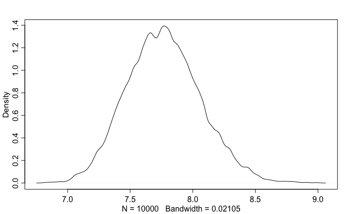

```r
dens(sample.sigma)
```

```r
HPDI(sample.mu)
```

```
   |0.89    0.89|
153.8693 155.1759
```

```r
HPDI(sample.sigma)
```

```
   |0.89    0.89|
7.266332 8.195980
```

### Fitting the model with `map`

```r
data("Howell1")
d <- Howell1
d2 <- d[d$age >= 18, ]
# Define the Model
flist <- alist(
  height ~ dnorm(mu, sigma),
  mu ~ dnorm(178, 20),
  sigma ~ dunif(0, 50)
)
# Fit the model
m4.1 <- map(flist, data = d2)
# Results
precis(m4.1)
```

|  | Mean | StdDev | 5.5% | 94.5% |
| --- | --- | --- | --- | --- |
| mu | 154.60 | 0.41 | 153.95 | 155.26 |
| sigma | 7.73 | 0.29 | 7.27 | 8.20 |

Now lets change the prior on $\mu$:

```r
m4.2 <- map(
  alist(height ~ dnorm(mu, sigma),
        mu ~ dnorm(178, 0.1),
        sigma ~ dunif(0, 50)),
  data = d2
)
# Results
precis(m4.2)
```

|  | Mean | StdDev | 5.5% | 94.5% |
| --- | --- | --- | --- | --- |
| mu | 177.86 | 0.10 | 177.70 | 178.02 |
| sigma | 24.52 | 0.93 | 23.03 | 26.00 |

Now, let’s sample vectors of values from a multi-dimensional Gaussian distribution:

```r
post <- extract.samples(m4.1, n = 10000)
head(post)
```

|  | mu | sigma |
| --- | --- | --- |
| 1 | 154.9075 | 8.074924 |
| 2 | 154.8106 | 7.960377 |
| 3 | 155.3331 | 7.881135 |
| 4 | 154.5251 | 7.619127 |
| 5 | 154.2843 | 8.097755 |
| 6 | 154.1572 | 8.052040 |

```r
precis(post)
```

|  | Mean | StdDev | \|0.89 | 0.89\| |
| --- | --- | --- | --- | --- |
| mu | 154.60 | 0.41 | 153.94 | 155.23 |
| sigma | 7.74 | 0.30 | 7.26 | 8.20 |

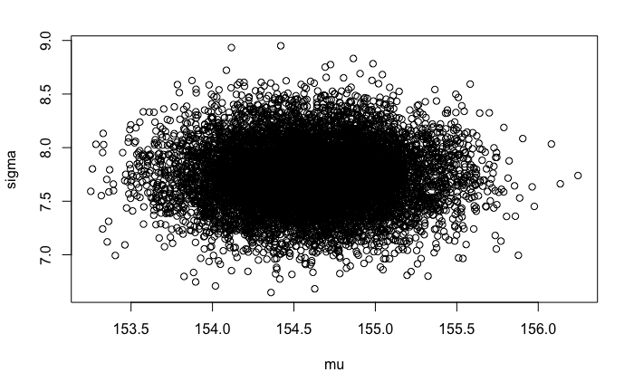

```r
plot(post)
```

## Adding a predictor

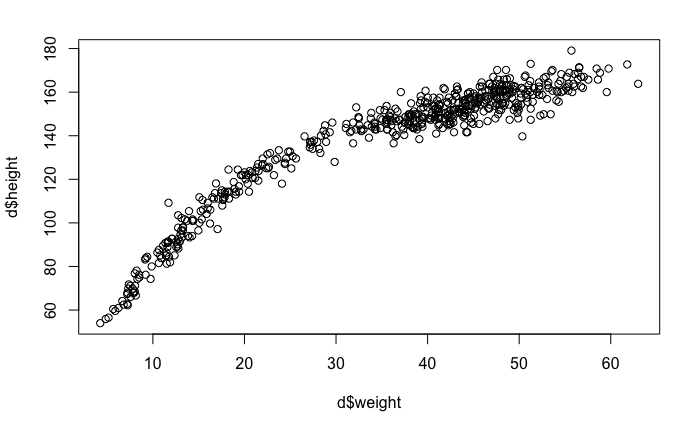

```r
plot(d$height ~ d$weight)
```

```r
m4.3 <- map(
  alist(height ~ dnorm(mu, sigma),
        mu <- a + b * weight,
        a ~ dnorm(156, 100),
        b ~ dnorm(0, 10),
        sigma ~ dunif(0, 50)),
  data = d2
)
# Results
precis(m4.3, corr = TRUE)
```

|  | Mean | StdDev | 5.5% | 94.5% | a | b | sigma |
| --- | --- | --- | --- | --- | --- | --- | --- |
| a | 113.90 | 1.91 | 110.85 | 116.94 | 1.00 | -0.99 | 0 |
| b | 0.90 | 0.04 | 0.84 | 0.97 | -0.99 | 1.00 | 0 |
| sigma | 5.07 | 0.19 | 4.77 | 5.38 | 0.00 | 0.00 | 1 |

Strong correlations between variables can be problematic. One way to fit this is to center the variables:

```r
d2$weight.c <- d2$weight - mean(d2$weight)
mean(d2$weight.c)
```

```
[1] 7.670718e-16
```

```r
# Now refit the model
m4.4 <- map(
  alist(height ~ dnorm(mu, sigma),
        mu <- a + b * weight.c,
        a ~ dnorm(156, 100),
        b ~ dnorm(0, 10),
        sigma ~ dunif(0, 50)),
  data = d2
)
# Results
precis(m4.4, corr = TRUE)
```

|  | Mean | StdDev | 5.5% | 94.5% | a | b | sigma |
| --- | --- | --- | --- | --- | --- | --- | --- |
| a | 154.60 | 0.27 | 154.17 | 155.03 | 1 | 0 | 0 |
| b | 0.91 | 0.04 | 0.84 | 0.97 | 0 | 1 | 0 |
| sigma | 5.07 | 0.19 | 4.77 | 5.38 | 0 | 0 | 1 |

To superimpose the MAP values for mean height over the actual data:

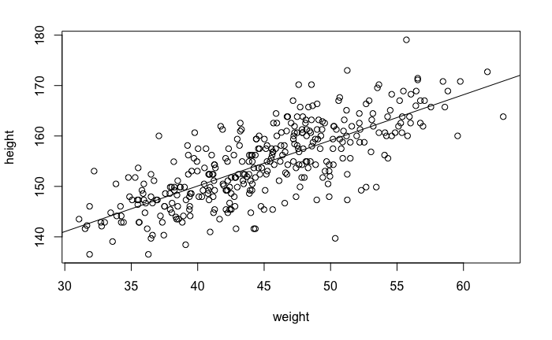

```r
plot(height ~ weight, data = d2)
abline(a = coef(m4.3)["a"], b = coef(m4.3)["b"])
```

```r
# Incorporate uncertanty
post <- extract.samples(m4.3)
head(post)
```

|  | a | b | sigma |
| --- | --- | --- | --- |
| 1 | 110.7519 | 0.9782701 | 5.300388 |
| 2 | 112.7805 | 0.9291860 | 5.068195 |
| 3 | 114.2471 | 0.8995404 | 5.023648 |
| 4 | 110.7126 | 0.9696639 | 5.160759 |
| 5 | 115.1343 | 0.8827769 | 5.404806 |
| 6 | 112.8627 | 0.9214979 | 5.056606 |

```r
N <- 300
dN <- d2[1:N, ]
mN <- map(
  alist(height ~ dnorm(mu, sigma),
        mu <- a + b * weight,
        a ~ dnorm(178, 100),
        b ~ dnorm(0, 10),
        sigma ~ dunif(0, 50)),
  data = dN
)
```

Now we plot 20 of these lines:

```r
# extract 20 samples from the posterior
post <- extract.samples(mN, n = 50)
# display raw data and sample size
plot(dN$weight, dN$height, xlim = range(d2$weight), ylim = range(d2$height),
     col = rangi2, xlab = "Weight", ylab = "Height")
mtext(concat("N = ", N))
```

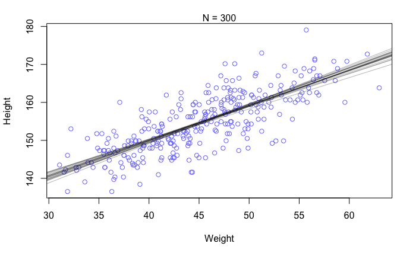

```r
# plot the lines, with transparency
for (i in 1:20) {
  abline(a = post$a[i], b = post$b[i], col = col.alpha("black", 0.3))
}
```

We could also plot an interval for uncertanty:

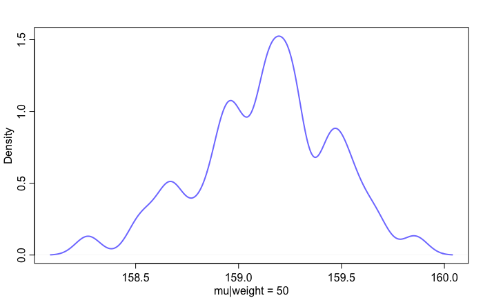

```r
mu_at_50 <- post$a + post$b * 50
dens(mu_at_50, col = rangi2, lwd = 2, xlab = "mu|weight = 50")
```

```r
mu <- link(m4.3)
```

```
[ 100 / 1000 ]
[ 200 / 1000 ]
[ 300 / 1000 ]
[ 400 / 1000 ]
[ 500 / 1000 ]
[ 600 / 1000 ]
[ 700 / 1000 ]
[ 800 / 1000 ]
[ 900 / 1000 ]
[ 1000 / 1000 ]
```

```r
str(mu)
```

```
 num [1:1000, 1:352] 157 157 157 157 157 ...
```

`link()` provides a posterior distribution for each indidivual in the data set, but we want a unique weight value for each $\mu$ on the horizontal axis:

```r
# define sequence of weights to compute predictions for these values will be
# on the horizontal axis
weight.seq <- seq(from = 25, to = 70, by = 1)
# use link to compute mu for each sample from the posterior and for each weight
# in weight.seq
mu <- link(m4.3, data = data.frame(weight = weight.seq))
```

```
[ 100 / 1000 ]
[ 200 / 1000 ]
[ 300 / 1000 ]
[ 400 / 1000 ]
[ 500 / 1000 ]
[ 600 / 1000 ]
[ 700 / 1000 ]
[ 800 / 1000 ]
[ 900 / 1000 ]
[ 1000 / 1000 ]
```

```r
str(mu)
```

```
 num [1:1000, 1:46] 139 135 136 137 137 ...
```

There are 46 columns in `mu` because we gave it 46 different values for weight.

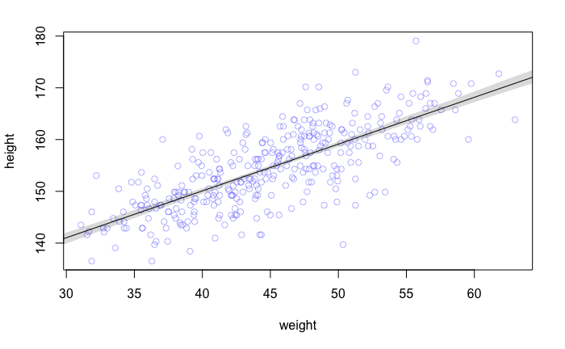

Here is the summary for generating predictions and intervals from the posterior of a fit model:

1. Use `link` to generate distributions of posterior values for $\mu$. The default behavior of `link` is to use the original data, so you have to pass it a list of new horizontal axis values you want to plot posterior predictions across.
2. Use summary functions like `mean` of `HPDI` or `PI` to find averages and lower and upper bounds of $\mu$ for each value of the predictor variable.
3. Finally, use plotting functions like `lines` and `shade` to draws the lines and intervals. Or you might plot the distributions of the predictions, or do further numerical calculations with them.

Now let’s plot predicted uncertainty:

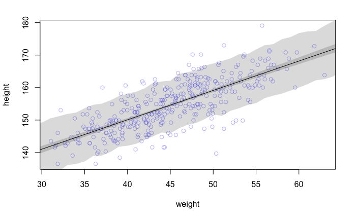

## Polynomial regression

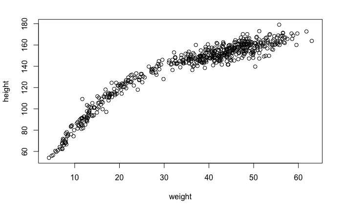

Now we standardize the variables:

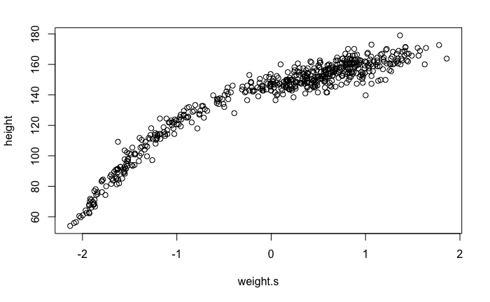

```r
d$weight.s2 <- d$weight.s^2

# Now refit the model
m4.5 <- map(
  alist(height ~ dnorm(mu, sigma),
        mu <- a + b1 * weight.s + b2 * weight.s2,
        a ~ dnorm(178, 100),
        b1 ~ dnorm(0, 10),
        b2 ~ dnorm(0, 10),
        sigma ~ dunif(0, 50)),
  data = d
)

# Results
precis(m4.5, corr = TRUE)
```

[output not shown]

Let’s plot the results:

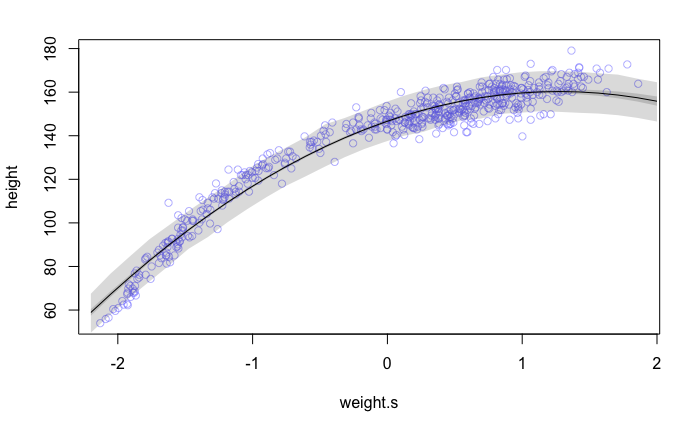

Now add in a cubic term:

```r
d$weight.s3 <- d$weight.s^3
# Now refit the model
m4.6 <- map(
  alist(height ~ dnorm(mu, sigma),
        mu <- a + b1 * weight.s + b2 * weight.s2 + b3 * weight.s3,
        a ~ dnorm(178, 100),
        b1 ~ dnorm(0, 10),
        b2 ~ dnorm(0, 10),
        b3 ~ dnorm(0, 10),
        sigma ~ dunif(0, 50)),
  data = d
)
# Results
precis(m4.6, corr = TRUE)
```

|  | Mean | StdDev | 5.5% | 94.5% | a | b1 | b2 | b3 | sigma |
| --- | --- | --- | --- | --- | --- | --- | --- | --- | --- |
| a | 146.73 | 0.31 | 146.23 | 147.23 | 1.00 | -0.21 | -0.66 | 0.01 | 0 |
| b1 | 15.02 | 0.48 | 14.25 | 15.80 | -0.21 | 1.00 | -0.17 | -0.86 | 0 |
| b2 | -6.53 | 0.27 | -6.96 | -6.11 | -0.66 | -0.17 | 1.00 | 0.46 | 0 |
| b3 | 3.59 | 0.24 | 3.22 | 3.97 | 0.01 | -0.86 | 0.46 | 1.00 | 0 |
| sigma | 4.82 | 0.15 | 4.59 | 5.05 | 0.00 | 0.00 | 0.00 | 0.00 | 1 |

Let’s plot the results:

```r
weight.seq <- seq(from = -2.2, to = 2, length.out = 30)
pred_dat <- list(weight.s = weight.seq, weight.s2 = weight.seq^2, weight.s3 = weight.seq^3)
mu <- link(m4.6, data = pred_dat)
```

```
[ 100 / 1000 ]
[ 200 / 1000 ]
[ 300 / 1000 ]
[ 400 / 1000 ]
[ 500 / 1000 ]
[ 600 / 1000 ]
[ 700 / 1000 ]
[ 800 / 1000 ]
[ 900 / 1000 ]
[ 1000 / 1000 ]
```

```r
mu.mean <- apply(mu, 2, mean)
mu.PI <- apply(mu, 2, PI, prob = 0.89)
sim.height <- sim(m4.6, data = pred_dat)
```

```
[ 100 / 1000 ]
[ 200 / 1000 ]
[ 300 / 1000 ]
[ 400 / 1000 ]
[ 500 / 1000 ]
[ 600 / 1000 ]
[ 700 / 1000 ]
[ 800 / 1000 ]
[ 900 / 1000 ]
[ 1000 / 1000 ]
```

```r
heights.PI <- apply(sim.height, 2, PI, prob = 0.89)
# plot
plot(height ~ weight.s, d, col = col.alpha(rangi2, 0.5))
lines(weight.seq, mu.mean)
```

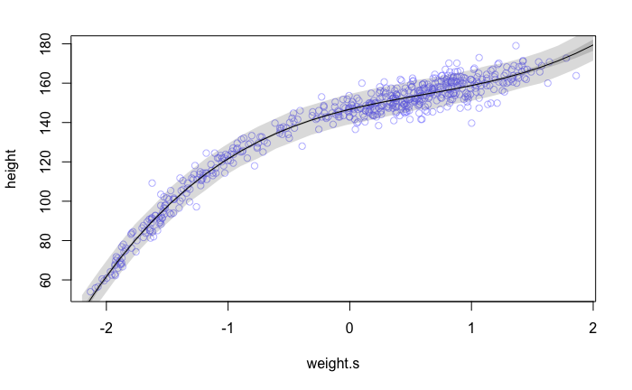

```r
shade(mu.PI, weight.seq)
shade(heights.PI, weight.seq)
```